# EXECUTIVE SUMMARY

**Business Challenge:** Generic marketing approach treating all 5,878 customers the same, leading to suboptimal spend allocation and missed revenue opportunities.

**Approach:** RFM (Recency, Frequency, Monetary) segmentation analysis identifying six distinct customer groups with different behaviors, needs, and values.

**Key Findings:**

- 31% of customers (VIPs) generate 75% of revenue
- 15% of customers (Slipping Regulars) represent £2.2M at-risk value; price is NOT the churn driver
- 4% of customers (Engaged Regulars) show high engagement but low spend—£137K monetization opportunity

**Recommended Actions:**

1. VIP retention program (protect £525K revenue)
2. Experience-focused win-back campaign (recover £660K)
3. Basket-building tactics for frequent low-spenders (unlock £87K)

**Next Steps:**

- Implement VIP loyalty program (Priority 1)
- Launch Slipping Regular win-back test (Priority 2)
- Deploy bundling strategy for Engaged Regulars (Priority 3)

```python
#import required packages
import pandas as pd
import numpy as np
import matplotlib.pyplot as plt
import seaborn as sns
```

```python
#  Load the CSV
data = pd.read_csv('online_retail_fast.csv')
data.head()
```

|  | Invoice | StockCode | Description | Quantity | InvoiceDate | Price | Customer ID | Country |
| --- | --- | --- | --- | --- | --- | --- | --- | --- |
| 0 | 489434 | 85048 | 15CM CHRISTMAS GLASS BALL 20 LIGHTS | 12 | 2009-12-01 07:45:00 | 6.95 | 13085.0 | United Kingdom |
| 1 | 489434 | 79323P | PINK CHERRY LIGHTS | 12 | 2009-12-01 07:45:00 | 6.75 | 13085.0 | United Kingdom |
| 2 | 489434 | 79323W | WHITE CHERRY LIGHTS | 12 | 2009-12-01 07:45:00 | 6.75 | 13085.0 | United Kingdom |
| 3 | 489434 | 22041 | RECORD FRAME 7" SINGLE SIZE | 48 | 2009-12-01 07:45:00 | 2.10 | 13085.0 | United Kingdom |
| 4 | 489434 | 21232 | STRAWBERRY CERAMIC TRINKET BOX | 24 | 2009-12-01 07:45:00 | 1.25 | 13085.0 | United Kingdom |

```python
#Examine for missing data
print(data.shape)
data.isna().sum()
```

```
(1067371, 8)
```

```
Invoice             0
StockCode           0
Description      4382
Quantity            0
InvoiceDate         0
Price               0
Customer ID    243007
Country             0
dtype: int64
```

```python
#Data Cleaning

#1. dropped the rows without a customer ID
data_clean = data[data['Customer ID'].notna()].copy()
print("This rows and columns for this dataset is ", data_clean.shape)

#2. Removed cancelled orders from the dataset
data_clean = data_clean[~data_clean['Invoice'].astype(str).str.startswith('C')]
data_clean.info()

#3. Converting the InvoiceDate column to a datetime object
data_clean['InvoiceDate'] = pd.to_datetime(data_clean['InvoiceDate'])
print(data_clean['InvoiceDate'].min())
print(data_clean['InvoiceDate'].max())

#4. Corrected the name for the customer id column
data_clean = data_clean.rename(columns={
    'Customer ID': 'CustomerID'
})
#5. Converted the data type of the customer Id Column
data_clean['CustomerID'] = data_clean['CustomerID'].astype(int)
```

```
This rows and columns for this dataset is  (824364, 8)
<class 'pandas.core.frame.DataFrame'>
Index: 805620 entries, 0 to 1067370
Data columns (total 8 columns):
 #   Column       Non-Null Count   Dtype
---  ------       --------------   -----
 0   Invoice      805620 non-null  object
 1   StockCode    805620 non-null  object
 2   Description  805620 non-null  object
 3   Quantity     805620 non-null  int64
 4   InvoiceDate  805620 non-null  object
 5   Price        805620 non-null  float64
 6   Customer ID  805620 non-null  float64
 7   Country      805620 non-null  object
dtypes: float64(2), int64(1), object(5)
memory usage: 55.3+ MB
2009-12-01 07:45:00
2011-12-09 12:50:00
```

```python
#Examining the dsummary statistics for the cleaned data
data_clean.describe()
```

|  | Quantity | InvoiceDate | Price | CustomerID |
| --- | --- | --- | --- | --- |
| count | 805620.000000 | 805620 | 805620.000000 | 805620.000000 |
| mean | 13.307665 | 2011-01-02 10:26:35.704326144 | 3.206279 | 15331.856250 |
| min | 1.000000 | 2009-12-01 07:45:00 | 0.000000 | 12346.000000 |
| 25% | 2.000000 | 2010-07-07 12:08:00 | 1.250000 | 13982.000000 |
| 50% | 5.000000 | 2010-12-03 15:10:00 | 1.950000 | 15271.000000 |
| 75% | 12.000000 | 2011-07-28 13:28:00 | 3.750000 | 16805.000000 |
| max | 80995.000000 | 2011-12-09 12:50:00 | 10953.500000 | 18287.000000 |
| std | 144.306739 | NaN | 29.197901 | 1696.768395 |

```python
#Conducting RFM analysis

# 1. First, we need a reference date (day after the last transaction)
reference_date = data_clean['InvoiceDate'].max() + pd.Timedelta(days=1)
print(f"Reference date: {reference_date}")

# 2. Create a TotalPrice column (Quantity * UnitPrice)
data_clean['TotalPrice'] = data_clean['Quantity'] * data_clean['Price']

#  Calculate RFM metrics for each customer
rfm = data_clean.groupby('CustomerID').agg({
    'InvoiceDate': lambda x: (reference_date - x.max()).days,  # Recency
    'Invoice': 'nunique',  # Frequency (number of unique invoices)
    'TotalPrice': 'sum'  # Monetary (total spent)
}).reset_index()

# Rename columns for clarity
rfm.columns = ['CustomerID', 'Recency', 'Frequency', 'Monetary']
```

```
Reference date: 2011-12-10 12:50:00
```

```python
#Examining the dsummary statistics for the RFM analysis


print("\nRFM Summary Statistics:")
rfm.describe()
```

```
RFM Summary Statistics:
```

|  | CustomerID | Recency | Frequency | Monetary |
| --- | --- | --- | --- | --- |
| count | 5881.000000 | 5881.000000 | 5881.000000 | 5881.000000 |
| mean | 15314.674205 | 201.457745 | 6.287196 | 3017.076888 |
| std | 1715.429759 | 209.474135 | 13.012879 | 14734.128619 |
| min | 12346.000000 | 1.000000 | 1.000000 | 0.000000 |
| 25% | 13833.000000 | 26.000000 | 1.000000 | 347.800000 |
| 50% | 15313.000000 | 96.000000 | 3.000000 | 897.620000 |
| 75% | 16797.000000 | 380.000000 | 7.000000 | 2304.180000 |
| max | 18287.000000 | 739.000000 | 398.000000 | 608821.650000 |

```python
#Examining the monetary column for discrepancies
print(rfm[rfm['Monetary'] <= 0])

#Filtering out the discrepancies
rfm_clean = rfm[rfm['Monetary'] > 0].copy()
rfm_clean.nlargest(10, 'Monetary')[['CustomerID', 'Recency', 'Frequency', 'Monetary']]
```

```
      CustomerID  Recency  Frequency  Monetary
904        13256       14          1       0.0
1739       14103      665          1       0.0
2458       14827      665          1       0.0
```

|  | CustomerID | Recency | Frequency | Monetary |
| --- | --- | --- | --- | --- |
| 5695 | 18102 | 1 | 145 | 608821.65 |
| 2279 | 14646 | 2 | 152 | 528602.52 |
| 1791 | 14156 | 10 | 156 | 313946.37 |
| 2541 | 14911 | 1 | 398 | 295972.63 |
| 5053 | 17450 | 8 | 51 | 246973.09 |
| 1332 | 13694 | 4 | 143 | 196482.81 |
| 5112 | 17511 | 3 | 60 | 175603.55 |
| 4064 | 16446 | 1 | 2 | 168472.50 |
| 4298 | 16684 | 4 | 55 | 147142.77 |
| 68 | 12415 | 24 | 28 | 144458.37 |

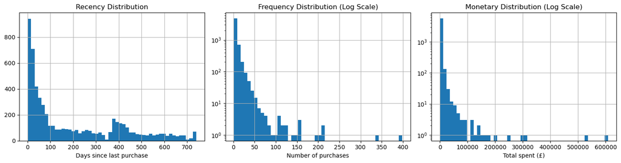

```python
# Visualizing the distribution of the RFM metrics
fig, axes = plt.subplots(1, 3, figsize=(15, 4))

# Recency (linear scale is fine)
rfm_clean['Recency'].hist(bins=50, ax=axes[0])
axes[0].set_title('Recency Distribution')
axes[0].set_xlabel('Days since last purchase')

# Frequency (log scale)
rfm_clean['Frequency'].hist(bins=50, ax=axes[1])
axes[1].set_yscale('log')
axes[1].set_title('Frequency Distribution (Log Scale)')
axes[1].set_xlabel('Number of purchases')

# Monetary (log scale)
rfm_clean['Monetary'].hist(bins=50, ax=axes[2])
axes[2].set_yscale('log')
axes[2].set_title('Monetary Distribution (Log Scale)')
axes[2].set_xlabel('Total spent (£)')

plt.tight_layout()
plt.show()
```

```python
#Exaining the summary statistics of the cleaned rfm analysis
rfm_clean.describe(percentiles=[.25, .5, .75, .90, .95, .99])
```

|  | CustomerID | Recency | Frequency | Monetary |
| --- | --- | --- | --- | --- |
| count | 5878.000000 | 5878.000000 | 5878.000000 | 5878.000000 |
| mean | 15315.313542 | 201.331916 | 6.289895 | 3018.616737 |
| std | 1715.572666 | 209.338707 | 13.015651 | 14737.731040 |
| min | 12346.000000 | 1.000000 | 1.000000 | 2.950000 |
| 25% | 13833.250000 | 26.000000 | 1.000000 | 348.762500 |
| 50% | 15314.500000 | 96.000000 | 3.000000 | 898.915000 |
| 75% | 16797.750000 | 380.000000 | 7.000000 | 2307.090000 |
| 90% | 17696.300000 | 535.000000 | 13.000000 | 5595.365000 |
| 95% | 17992.150000 | 625.000000 | 21.000000 | 9535.336000 |
| 99% | 18228.230000 | 726.000000 | 46.000000 | 29730.420200 |
| max | 18287.000000 | 739.000000 | 398.000000 | 608821.650000 |

```python
# Create RFM scores using quartiles (1-4 scale)
rfm_clean['R_Score'] = pd.qcut(rfm_clean['Recency'], q=4, labels=[4, 3, 2, 1])  # Lower recency = better = higher score
rfm_clean['F_Score'] = pd.qcut(rfm_clean['Frequency'].rank(method='first'), q=4, labels=[1, 2, 3, 4])  # Higher frequency = higher score
rfm_clean['M_Score'] = pd.qcut(rfm_clean['Monetary'], q=4, labels=[1, 2, 3, 4])  # Higher monetary = higher score

# Combine into RFM Score
rfm_clean['RFM_Score'] = rfm_clean['R_Score'].astype(str) + rfm_clean['F_Score'].astype(str) + rfm_clean['M_Score'].astype(str)


# Count customers by score
print("\nTop 10 RFM Score combinations:")
rfm_clean['RFM_Score'].value_counts().head(10)
```

```
Top 10 RFM Score combinations:
```

```
RFM_Score
444    661
111    575
344    345
211    253
233    234
333    226
222    222
122    212
433    208
121    160
Name: count, dtype: int64
```

```python
#Classifying customer RFM score into categories

def rfm_segment_v2(row):
    r, f, m = int(row['R_Score']), int(row['F_Score']), int(row['M_Score'])

    # 1. VIP Customers (High F, High R, High M)
    if f >= 3 and r >= 3 and m >= 3:
        return 'VIP Customers'

    # 2. Loyal Actives (High F, High R, Low M)
    elif f > 2 and r >= 3 and m <= 2:
        return 'Engaged Regulars'

    # 3. Slipping Loyals (High F, Low R, Any M)
    elif f >= 3 and r <= 2:
        return 'Slipping Regulars'

    # 4. Promising Newcomers (Low F, High R, Any M)
    elif f <= 2 and r >= 3:
        return 'Promising Newcomers'

    # 5. One-Time Big Spenders (Low F, Any R, High M)
    elif f <= 2 and m == 4:
        return 'One-Time Big Spenders'

    # 6. Dormant/Lost (Low F, Low R, Any M)
    elif f <= 2 and r <= 2:
        return 'Dormant/Lost'

    else:
        return 'Others'

# Apply the new segmentation
rfm_clean['Segment_v2'] = rfm_clean.apply(rfm_segment_v2, axis=1)

# Check results
print("Customer Segments :")
segment_counts_v2 = rfm_clean['Segment_v2'].value_counts()
print(segment_counts_v2)

print("\nPercentage breakdown:")
print((segment_counts_v2 / len(rfm_clean) * 100).round(2))

# Check for any "Others"
print(f"\nCustomers in 'Others' category: {segment_counts_v2.get('Others', 0)}")

# Summary stats by segment
print("\nAverage metrics by segment:")
segment_summary = rfm_clean.groupby('Segment_v2')[['Recency', 'Frequency', 'Monetary']].mean().round(2)
print(segment_summary)
```

```
Customer Segments :
Segment_v2
Dormant/Lost             2009
VIP Customers            1814
Promising Newcomers       894
Slipping Regulars         880
Engaged Regulars          245
One-Time Big Spenders      36
Name: count, dtype: int64

Percentage breakdown:
Segment_v2
Dormant/Lost             34.18
VIP Customers            30.86
Promising Newcomers      15.21
Slipping Regulars        14.97
Engaged Regulars          4.17
One-Time Big Spenders     0.61
Name: count, dtype: float64

Customers in 'Others' category: 0

Average metrics by segment:
                       Recency  Frequency  Monetary
Segment_v2
Dormant/Lost            412.14       1.47    435.62
Engaged Regulars         33.64       4.10    624.17
One-Time Big Spenders   378.89       2.11   7227.05
Promising Newcomers      40.72       1.78    861.25
Slipping Regulars       277.12       6.53   2524.64
VIP Customers            29.37      14.11   7422.02
```

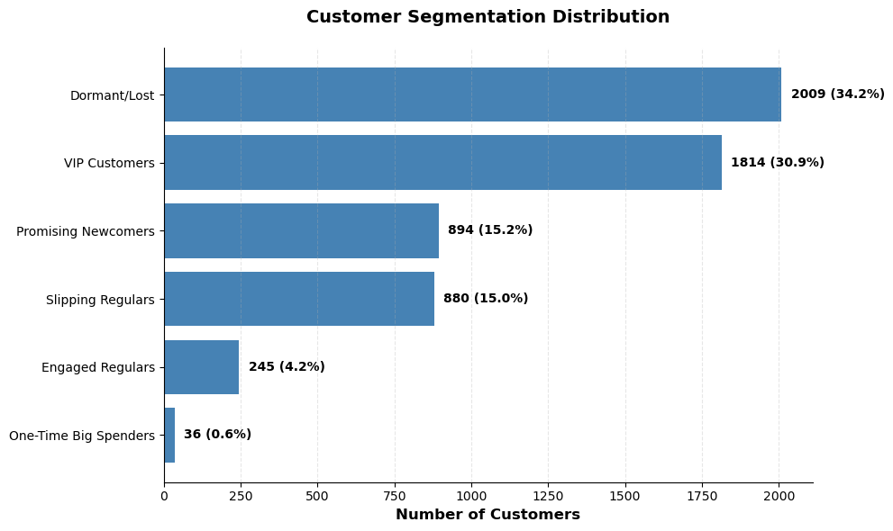

```
Segment Summary:
                       Count  Percentage
Segment_v2
Dormant/Lost            2009        34.2
VIP Customers           1814        30.9
Promising Newcomers      894        15.2
Slipping Regulars        880        15.0
Engaged Regulars         245         4.2
One-Time Big Spenders     36         0.6
```

```python
#Visualizing the segments
# Get segment counts and percentages
segment_percentages = (segment_counts_v2 / len(rfm_clean) * 100).round(1)

# Sort by count (descending)
segment_counts_sorted = segment_counts_v2.sort_values(ascending=True)  # True for horizontal bars
segment_percentages_sorted = segment_percentages[segment_counts_sorted.index]

# Create the plot
fig, ax = plt.subplots(figsize=(10, 6))

# Create horizontal bars
bars = ax.barh(segment_counts_sorted.index, segment_counts_sorted.values, color='steelblue')

# Add count and percentage labels on the bars
for i, (count, pct) in enumerate(zip(segment_counts_sorted.values, segment_percentages_sorted.values)):
    ax.text(count + 30, i, f'{count} ({pct}%)',
            va='center', fontsize=10, fontweight='bold')

# Formatting
ax.set_xlabel('Number of Customers', fontsize=12, fontweight='bold')
ax.set_title('Customer Segmentation Distribution', fontsize=14, fontweight='bold', pad=20)
ax.spines['top'].set_visible(False)
ax.spines['right'].set_visible(False)

# Add grid for easier reading
ax.grid(axis='x', alpha=0.3, linestyle='--')

plt.tight_layout()
plt.show()

# Optional: Print summary table
print("\nSegment Summary:")
summary_df = pd.DataFrame({
    'Count': segment_counts_v2,
    'Percentage': segment_percentages
}).sort_values('Count', ascending=False)
print(summary_df)
```

```
Average Metrics by Segment:
                       Recency  Frequency  Monetary
Segment_v2
VIP Customers            29.37      14.11   7422.02
One-Time Big Spenders   378.89       2.11   7227.05
Slipping Regulars       277.12       6.53   2524.64
Promising Newcomers      40.72       1.78    861.25
Engaged Regulars         33.64       4.10    624.17
Dormant/Lost            412.14       1.47    435.62
```

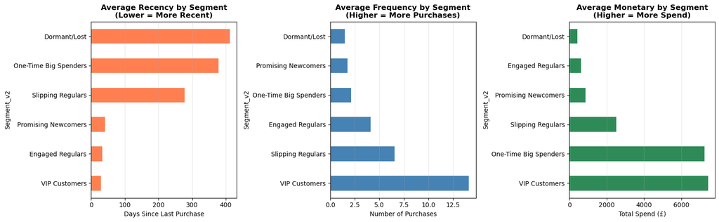

```python
# Calculate average metrics by segment
segment_profile = rfm_clean.groupby('Segment_v2')[['Recency', 'Frequency', 'Monetary']].mean().round(2)

# Sort by Monetary (most valuable first)
segment_profile = segment_profile.sort_values('Monetary', ascending=False)

print("Average Metrics by Segment:")
print(segment_profile)

# Create comparison visualization
fig, axes = plt.subplots(1, 3, figsize=(16, 5))

# Plot 1: Average Recency by Segment
segment_profile.sort_values('Recency')['Recency'].plot(
    kind='barh',
    ax=axes[0],
    color='coral'
)
axes[0].set_title('Average Recency by Segment\n(Lower = More Recent)', fontweight='bold', fontsize=12)
axes[0].set_xlabel('Days Since Last Purchase')
axes[0].grid(axis='x', alpha=0.3)

# Plot 2: Average Frequency by Segment
segment_profile.sort_values('Frequency', ascending=False)['Frequency'].plot(
    kind='barh',
    ax=axes[1],
    color='steelblue'
)
axes[1].set_title('Average Frequency by Segment\n(Higher = More Purchases)', fontweight='bold', fontsize=12)
axes[1].set_xlabel('Number of Purchases')
axes[1].grid(axis='x', alpha=0.3)

# Plot 3: Average Monetary by Segment
segment_profile.sort_values('Monetary', ascending=False)['Monetary'].plot(
    kind='barh',
    ax=axes[2],
    color='seagreen'
)
axes[2].set_title('Average Monetary by Segment\n(Higher = More Spend)', fontweight='bold', fontsize=12)
axes[2].set_xlabel('Total Spend (£)')
axes[2].grid(axis='x', alpha=0.3)

plt.tight_layout()
plt.show()
```

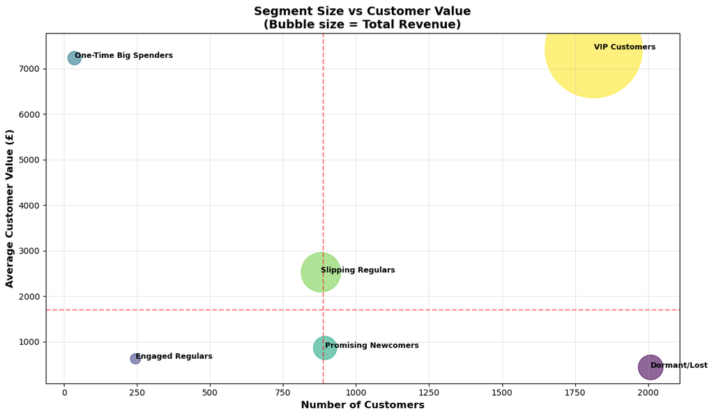

```
Segment Summary:
                       num_customers     Monetary  Recency  Frequency  \
Segment_v2
Dormant/Lost                    2009    875155.54   412.14       1.47
Engaged Regulars                 245    152920.97    33.64       4.10
One-Time Big Spenders             36    260173.62   378.89       2.11
Promising Newcomers              894    769953.17    40.72       1.78
Slipping Regulars                880   2221679.29   277.12       6.53
VIP Customers                   1814  13463546.58    29.37      14.11

                       avg_customer_value
Segment_v2
Dormant/Lost                       435.62
Engaged Regulars                   624.17
One-Time Big Spenders             7227.05
Promising Newcomers                861.25
Slipping Regulars                 2524.64
VIP Customers                     7422.02
```

```python
#Visualizing the monetary value of segments against teh number of customers in that segment

# Calculate segment metrics
segment_summary = rfm_clean.groupby('Segment_v2').agg({
    'CustomerID': 'count',           # Number of customers
    'Monetary': 'sum',               # Total revenue
    'Recency': 'mean',               # Avg recency
    'Frequency': 'mean'              # Avg frequency
}).rename(columns={'CustomerID': 'num_customers'})

segment_summary['avg_customer_value'] = segment_summary['Monetary'] / segment_summary['num_customers']

# Create scatter plot
plt.figure(figsize=(12, 7))

scatter = plt.scatter(
    segment_summary['num_customers'],
    segment_summary['avg_customer_value'],
    s=segment_summary['Monetary']/1000,  # Size = total revenue
    alpha=0.6,
    c=range(len(segment_summary)),
    cmap='viridis'
)

# Add labels for each point
for idx, row in segment_summary.iterrows():
    plt.annotate(
        idx,
        (row['num_customers'], row['avg_customer_value']),
        fontsize=9,
        fontweight='bold'
    )

plt.xlabel('Number of Customers', fontsize=12, fontweight='bold')
plt.ylabel('Average Customer Value (£)', fontsize=12, fontweight='bold')
plt.title('Segment Size vs Customer Value\n(Bubble size = Total Revenue)', fontsize=14, fontweight='bold')
plt.grid(alpha=0.3)

# Add quadrant lines (optional - shows strategic positioning)
plt.axhline(segment_summary['avg_customer_value'].median(), color='red', linestyle='--', alpha=0.5)
plt.axvline(segment_summary['num_customers'].median(), color='red', linestyle='--', alpha=0.5)

plt.tight_layout()
plt.show()

# Print the summary table
print("\nSegment Summary:")
print(segment_summary.round(2))
```

```python
# Enhanced Slipping Regulars Product Analysis
slipping_customers = rfm_clean[rfm_clean['Segment_v2'] == 'Slipping Regulars']['CustomerID']
slipping_purchases = data_clean[data_clean['CustomerID'].isin(slipping_customers)].copy()

# Get product stats for slipping customers
# Use idx to get price at actual last purchase date
product_analysis = slipping_purchases.sort_values('InvoiceDate').groupby('Description').agg({
    'Quantity': 'sum',
    'CustomerID': 'nunique',
    'Price': 'last',  # Last price (after sorting by date)
    'InvoiceDate': 'max'  # Last purchase date
}).round(2)

product_analysis.columns = ['slipping_qty', 'slipping_customers', 'slipping_price', 'slipping_last_date']

# Days since slipping customers bought this
product_analysis['days_since_slipping_purchase'] = (reference_date - product_analysis['slipping_last_date']).dt.days

# Get overall market activity for these same products
slipping_products_list = product_analysis.index.tolist()
recent_activity = data_clean[data_clean['Description'].isin(slipping_products_list)].sort_values('InvoiceDate').groupby('Description').agg({
    'InvoiceDate': 'max',
    'Price': 'last'
}).reset_index()

recent_activity.columns = ['Description', 'overall_last_date', 'overall_last_price']
recent_activity['days_since_overall_purchase'] = (reference_date - recent_activity['overall_last_date']).dt.days

# Merge
product_comparison = product_analysis.merge(recent_activity, on='Description')

# Flag if product died after slipping customers stopped buying
product_comparison['dead_since_slipping'] = product_comparison['days_since_overall_purchase'] > product_comparison['days_since_slipping_purchase']

# Price change analysis
product_comparison['price_diff'] = product_comparison['overall_last_price'] - product_comparison['slipping_price']
product_comparison['price_change_pct'] = (product_comparison['price_diff'] / product_comparison['slipping_price'] * 100).round(1)

# Sort by slipping customers (most popular first)
product_comparison = product_comparison.sort_values('slipping_customers', ascending=False)

print("Product Comparison for Slipping Regulars:")
product_comparison.head(20)
```

```
Product Comparison for Slipping Regulars:
```

|  | Description | slipping_qty | slipping_customers | slipping_price | slipping_last_date | days_since_slipping_purchase | overall_last_date | overall_last_price | days_since_overall_purchase | dead_since_slipping | price_diff | price_change_pct |
| --- | --- | --- | --- | --- | --- | --- | --- | --- | --- | --- | --- | --- |
| 4249 | WHITE HANGING HEART T-LIGHT HOLDER | 14605 | 318 | 2.95 | 2011-09-04 12:49:00 | 97 | 2011-12-08 19:55:00 | 2.95 | 1 | False | 0.00 | 0.0 |
| 3177 | REGENCY CAKESTAND 3 TIER | 2320 | 251 | 10.95 | 2011-09-02 15:20:00 | 98 | 2011-12-09 10:20:00 | 12.75 | 1 | False | 1.80 | 16.4 |
| 312 | BAKING SET 9 PIECE RETROSPOT | 1096 | 175 | 4.95 | 2011-08-28 10:21:00 | 104 | 2011-12-09 12:50:00 | 4.95 | 1 | False | 0.00 | 0.0 |
| 250 | ASSORTED COLOUR BIRD ORNAMENT | 7349 | 173 | 1.69 | 2011-08-31 10:42:00 | 101 | 2011-12-09 12:31:00 | 1.69 | 1 | False | 0.00 | 0.0 |
| 1869 | HEART OF WICKER SMALL | 3790 | 168 | 1.65 | 2011-08-12 14:33:00 | 119 | 2011-12-09 11:34:00 | 1.65 | 1 | False | 0.00 | 0.0 |
| 2637 | PARTY BUNTING | 3347 | 164 | 4.95 | 2011-08-30 16:43:00 | 101 | 2011-12-08 15:31:00 | 4.95 | 1 | False | 0.00 | 0.0 |
| 140 | 60 TEATIME FAIRY CAKE CASES | 14134 | 164 | 0.55 | 2011-08-26 14:04:00 | 105 | 2011-12-08 15:31:00 | 0.55 | 1 | False | 0.00 | 0.0 |
| 1868 | HEART OF WICKER LARGE | 2447 | 162 | 2.95 | 2011-08-31 16:09:00 | 100 | 2011-12-08 17:54:00 | 2.95 | 1 | False | 0.00 | 0.0 |
| 3071 | RED HANGING HEART T-LIGHT HOLDER | 3030 | 154 | 2.95 | 2011-08-24 14:23:00 | 107 | 2011-12-08 14:38:00 | 2.95 | 1 | False | 0.00 | 0.0 |
| 2191 | LOVE BUILDING BLOCK WORD | 1077 | 154 | 5.95 | 2011-08-28 11:01:00 | 104 | 2011-12-09 12:00:00 | 6.25 | 1 | False | 0.30 | 5.0 |
| 1903 | HOME BUILDING BLOCK WORD | 1165 | 152 | 5.95 | 2011-08-28 15:27:00 | 103 | 2011-12-08 13:59:00 | 6.25 | 1 | False | 0.30 | 5.0 |
| 3904 | STRAWBERRY CERAMIC TRINKET BOX | 7566 | 151 | 1.25 | 2011-08-22 13:30:00 | 109 | 2011-12-01 11:18:00 | 1.06 | 9 | False | -0.19 | -15.2 |
| 2420 | NATURAL SLATE HEART CHALKBOARD | 1974 | 148 | 2.95 | 2011-08-26 12:36:00 | 106 | 2011-12-09 08:59:00 | 2.95 | 1 | False | 0.00 | 0.0 |
| 3251 | REX CASH+CARRY JUMBO SHOPPER | 642 | 146 | 0.95 | 2011-08-30 16:43:00 | 101 | 2011-12-08 18:42:00 | 0.95 | 1 | False | 0.00 | 0.0 |
| 4433 | ZINC METAL HEART DECORATION | 2626 | 134 | 1.25 | 2011-08-24 14:23:00 | 107 | 2011-12-08 14:38:00 | 1.25 | 1 | False | 0.00 | 0.0 |
| 2021 | JUMBO BAG RED RETROSPOT | 7729 | 133 | 2.08 | 2011-09-02 09:45:00 | 99 | 2011-12-09 09:38:00 | 2.08 | 1 | False | 0.00 | 0.0 |
| 2563 | PACK OF 60 PINK PAISLEY CAKE CASES | 9421 | 133 | 0.55 | 2011-08-28 11:55:00 | 104 | 2011-12-08 15:31:00 | 0.55 | 1 | False | 0.00 | 0.0 |
| 2565 | PACK OF 72 RETRO SPOT CAKE CASES | 9009 | 133 | 0.55 | 2010-11-24 16:16:00 | 380 | 2010-11-24 16:16:00 | 0.55 | 380 | False | 0.00 | 0.0 |
| 1368 | FELTCRAFT 6 FLOWER FRIENDS | 1743 | 131 | 2.10 | 2011-08-17 14:25:00 | 114 | 2011-11-10 18:46:00 | 1.85 | 29 | False | -0.25 | -11.9 |
| 3399 | SCOTTIE DOG HOT WATER BOTTLE | 939 | 129 | 4.95 | 2011-08-24 14:23:00 | 107 | 2011-12-09 11:26:00 | 4.95 | 1 | False | 0.00 | 0.0 |

```python
# Summary statistics of slippinf regulars
total_products = len(product_comparison)
dead_products = product_comparison['dead_since_slipping'].sum()
price_increased = (product_comparison['price_change_pct'] > 0).sum()
price_decreased = (product_comparison['price_change_pct'] < 0).sum()
price_stable = (product_comparison['price_change_pct'] == 0).sum()

# Significant price changes (>10% up or down)
sig_price_increase = (product_comparison['price_change_pct'] > 10).sum()
sig_price_decrease = (product_comparison['price_change_pct'] < -10).sum()

print("=== SLIPPING REGULARS PRODUCT ANALYSIS ===\n")
print(f"Total products analyzed: {total_products}")
print(f"Products discontinued after slipping customers left: {dead_products} ({dead_products/total_products*100:.1f}%)")
print(f"\nPrice Changes:")
print(f"  Increased: {price_increased} ({price_increased/total_products*100:.1f}%)")
print(f"  Decreased: {price_decreased} ({price_decreased/total_products*100:.1f}%)")
print(f"  Stable: {price_stable} ({price_stable/total_products*100:.1f}%)")
print(f"\nSignificant price changes (>10%):")
print(f"  Increases >10%: {sig_price_increase} ({sig_price_increase/total_products*100:.1f}%)")
print(f"  Decreases >10%: {sig_price_decrease} ({sig_price_decrease/total_products*100:.1f}%)")

# Focus on top products (bought by 5+ slipping customers)
top_products = product_comparison[product_comparison['slipping_customers'] >= 5]
print(f"\n=== TOP PRODUCTS (5+ slipping customers bought them) ===")
print(f"Total: {len(top_products)}")
print(f"Price increased: {(top_products['price_change_pct'] > 10).sum()}")
print(f"Price decreased: {(top_products['price_change_pct'] < -10).sum()}")
print(f"Discontinued: {top_products['dead_since_slipping'].sum()}")
```

```
=== SLIPPING REGULARS PRODUCT ANALYSIS ===

Total products analyzed: 4442
Products discontinued after slipping customers left: 0 (0.0%)

Price Changes:
  Increased: 264 (5.9%)
  Decreased: 671 (15.1%)
  Stable: 3507 (79.0%)

Significant price changes (>10%):
  Increases >10%: 242 (5.4%)
  Decreases >10%: 646 (14.5%)

=== TOP PRODUCTS (5+ slipping customers bought them) ===
Total: 2988
Price increased: 181
Price decreased: 429
Discontinued: 0
```

```
Rows with NaN/inf in price_change_pct: 1
Clean rows for visualization: 4441
```

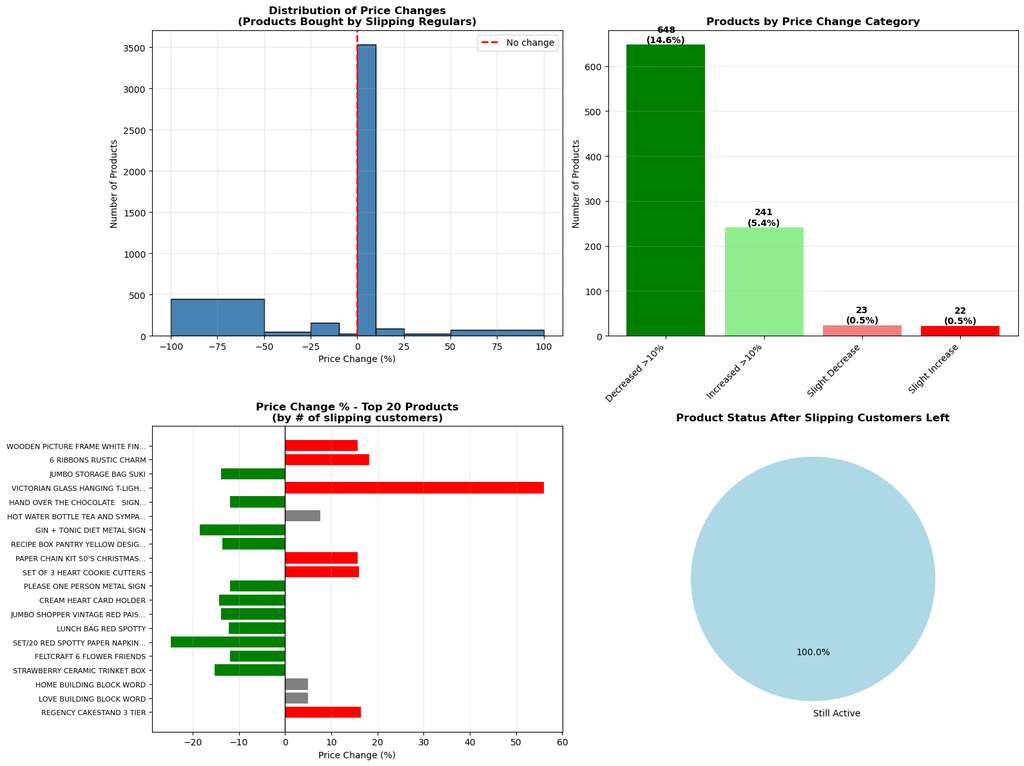

```python
#Examining the products bought by slipping regulars
# Remove infinite and NaN values
product_comparison_clean = product_comparison.copy()

# Replace inf/-inf with NaN, then drop them
product_comparison_clean['price_change_pct'] = product_comparison_clean['price_change_pct'].replace([np.inf, -np.inf], np.nan)

# Check how many bad values
print(f"Rows with NaN/inf in price_change_pct: {product_comparison_clean['price_change_pct'].isna().sum()}")

# Drop rows with NaN in price_change_pct for visualization
product_comparison_viz = product_comparison_clean.dropna(subset=['price_change_pct'])

print(f"Clean rows for visualization: {len(product_comparison_viz)}")

fig, axes = plt.subplots(2, 2, figsize=(16, 12))

# ===== VIZ 1: Price Change Distribution =====
axes[0, 0].hist(product_comparison_viz['price_change_pct'], bins= [-100, -50, -25, -10, 0, 10, 25, 50, 100], color='steelblue', edgecolor='black')
axes[0, 0].axvline(0, color='red', linestyle='--', linewidth=2, label='No change')
axes[0, 0].set_title('Distribution of Price Changes\n(Products Bought by Slipping Regulars)',
                      fontweight='bold', fontsize=12)
axes[0, 0].set_xlabel('Price Change (%)')
axes[0, 0].set_ylabel('Number of Products')
axes[0, 0].legend()
axes[0, 0].grid(alpha=0.3)

# ===== VIZ 2: Price Change Categories (Bar) =====
non_zero_data = product_comparison_viz[product_comparison_viz['price_change_pct'] != 0]
price_categories = pd.cut(non_zero_data['price_change_pct'],
                          bins=[-float('inf'), -10, 0, 10, float('inf')],
                          labels=['Decreased >10%', 'Slight Decrease', 'Slight Increase', 'Increased >10%'])
price_cat_counts = price_categories.value_counts()

axes[0, 1].bar(range(len(price_cat_counts)), price_cat_counts.values,
               color=['green', 'lightgreen', 'lightcoral', 'red'])
axes[0, 1].set_xticks(range(len(price_cat_counts)))
axes[0, 1].set_xticklabels(price_cat_counts.index, rotation=45, ha='right')
axes[0, 1].set_title('Products by Price Change Category', fontweight='bold', fontsize=12)
axes[0, 1].set_ylabel('Number of Products')
axes[0, 1].grid(axis='y', alpha=0.3)

# Add percentage labels on bars
for i, v in enumerate(price_cat_counts.values):
    pct = v / len(product_comparison_viz) * 100
    axes[0, 1].text(i, v + 5, f'{v}\n({pct:.1f}%)', ha='center', fontweight='bold')

# ===== VIZ 3: Top 20 Products - Price Change =====
top_20 = non_zero_data.sort_values('slipping_customers', ascending=False).head(20).reset_index()

colors = ['red' if x > 10 else 'green' if x < -10 else 'gray' for x in top_20['price_change_pct']]

axes[1, 0].barh(range(len(top_20)), top_20['price_change_pct'], color=colors)
axes[1, 0].set_yticks(range(len(top_20)))
axes[1, 0].set_yticklabels([desc[:30] + '...' if len(str(desc)) > 30 else desc
                             for desc in top_20['Description']], fontsize=8)
axes[1, 0].axvline(0, color='black', linestyle='-', linewidth=1)
axes[1, 0].set_title('Price Change % - Top 20 Products\n(by # of slipping customers)',
                      fontweight='bold', fontsize=12)
axes[1, 0].set_xlabel('Price Change (%)')
axes[1, 0].grid(axis='x', alpha=0.3)

# ===== VIZ 4: Dead vs Active Products =====
# FIX: Handle cases where all products are active OR all discontinued
status_counts = product_comparison_viz['dead_since_slipping'].value_counts()

# Create labels dynamically based on what exists
actual_labels = []
actual_values = []
actual_colors = []

if False in status_counts.index:
    actual_labels.append('Still Active')
    actual_values.append(status_counts[False])
    actual_colors.append('lightblue')

if True in status_counts.index:
    actual_labels.append('Discontinued')
    actual_values.append(status_counts[True])
    actual_colors.append('lightcoral')

axes[1, 1].pie(actual_values, labels=actual_labels, autopct='%1.1f%%',
               colors=actual_colors, startangle=90)
axes[1, 1].set_title('Product Status After Slipping Customers Left',
                      fontweight='bold', fontsize=12)

plt.tight_layout()
plt.show()
```

```
Average Order Value by Segment:
                          mean   median     min       max
Segment_v2
Dormant/Lost            297.57   234.00    2.95   2300.40
Engaged Regulars        161.97   157.26    7.74    298.87
One-Time Big Spenders  3728.79  2116.26  860.25  14844.77
Promising Newcomers     468.68   294.17    6.20  84236.25
Slipping Regulars       353.82   280.12   11.16   6819.05
VIP Customers           441.25   344.11   29.96   5159.23
```

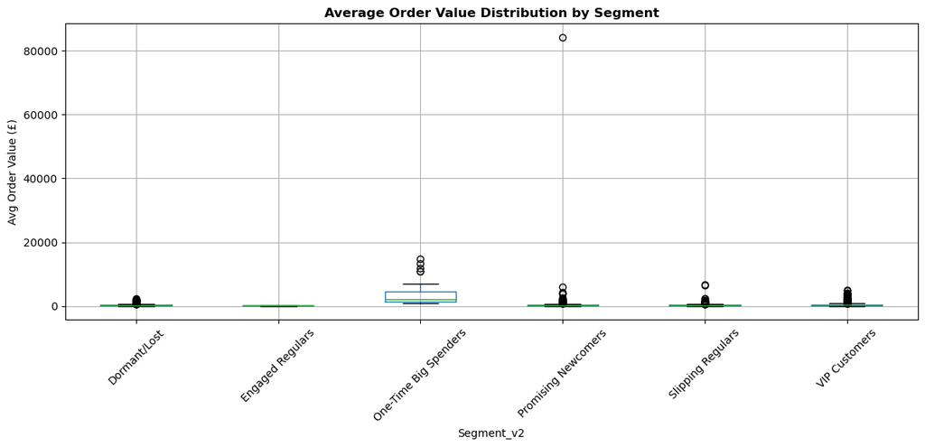

```python
#Evaluating the montera value per unit order of a customer
 # Calculate average order value (AOV)
rfm_clean['Avg_Order_Value'] = rfm_clean['Monetary'] / rfm_clean['Frequency']

# Analyze by segment
aov_analysis = rfm_clean.groupby('Segment_v2')['Avg_Order_Value'].agg(['mean', 'median', 'min', 'max']).round(2)

print("Average Order Value by Segment:")
print(aov_analysis)

# Visualize
import matplotlib.pyplot as plt

rfm_clean.boxplot(column='Avg_Order_Value', by='Segment_v2', figsize=(12, 6))
plt.suptitle('')
plt.title('Average Order Value Distribution by Segment', fontweight='bold')
plt.ylabel('Avg Order Value (£)')
plt.xticks(rotation=45)
plt.tight_layout()
plt.show()
```

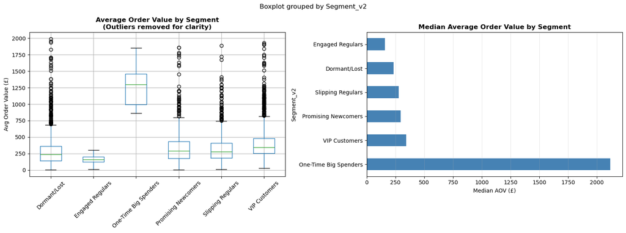

```python
#Visualizing the AOV
# Remove extreme outliers for better visualization
threshold_99 = rfm_clean['Avg_Order_Value'].quantile(0.99)
rfm_viz = rfm_clean[rfm_clean['Avg_Order_Value'] <= threshold_99]

# Create side-by-side comparison
fig, axes = plt.subplots(1, 2, figsize=(16, 6))

# Plot 1: Boxplot (cleaned)
rfm_viz.boxplot(column='Avg_Order_Value', by='Segment_v2', ax=axes[0])
axes[0].set_title('Average Order Value by Segment\n(Outliers removed for clarity)', fontweight='bold')
axes[0].set_ylabel('Avg Order Value (£)')
axes[0].set_xlabel('')
plt.sca(axes[0])
plt.xticks(rotation=45)

# Plot 2: Bar chart of medians (clearer story)
median_aov = rfm_clean.groupby('Segment_v2')['Avg_Order_Value'].median().sort_values(ascending=False)
median_aov.plot(kind='barh', ax=axes[1], color='steelblue')
axes[1].set_title('Median Average Order Value by Segment', fontweight='bold')
axes[1].set_xlabel('Median AOV (£)')
axes[1].grid(axis='x', alpha=0.3)

plt.tight_layout()
plt.show()
```

```python
#Evalauting products bought by VIP customers
# Get VIP customer IDs
vip_customers = rfm_clean[rfm_clean['Segment_v2'] == 'VIP Customers']['CustomerID']

# Get their purchases
vip_purchases = data_clean[data_clean['CustomerID'].isin(vip_customers)]

# Top products
print("Top 20 Products Bought by VIP Customers:")
vip_products = vip_purchases.groupby('Description').agg({
    'Quantity': 'sum',
    'CustomerID': 'nunique',
    'TotalPrice': 'sum'
}).sort_values('CustomerID', ascending=False).head(20)

print(vip_products)

# % of VIPs who bought each product
vip_products['penetration_%'] = (vip_products['CustomerID'] / len(vip_customers) * 100).round(1)
print(vip_products)
```

```
Top 20 Products Bought by VIP Customers:
                                    Quantity  CustomerID  TotalPrice
Description
WHITE HANGING HEART T-LIGHT HOLDER     69266         698   186499.52
REGENCY CAKESTAND 3 TIER               20999         696   240241.95
BAKING SET 9 PIECE RETROSPOT            6306         566    29847.96
PAPER CHAIN KIT 50'S CHRISTMAS         22900         546    61825.78
ASSORTED COLOUR BIRD ORNAMENT          66420         534   105015.24
JUMBO BAG RED RETROSPOT                64718         532   116946.61
PARTY BUNTING                          18735         513    81929.33
HEART OF WICKER SMALL                  21150         503    35389.75
PACK OF 72 RETROSPOT CAKE CASES        34275         498    16720.18
NATURAL SLATE HEART CHALKBOARD         11020         491    31135.12
LUNCH BAG SPACEBOY DESIGN              14461         479    23171.05
60 TEATIME FAIRY CAKE CASES            35322         469    17556.82
PAPER CHAIN KIT VINTAGE CHRISTMAS      14829         464    40240.27
HEART OF WICKER LARGE                  14067         447    41225.03
VINTAGE SNAP CARDS                     19523         440    15332.49
LUNCH BAG  BLACK SKULL.                18827         438    29832.15
LUNCH BAG CARS BLUE                    16458         437    26058.38
PACK OF 60 PINK PAISLEY CAKE CASES     41994         435    20391.65
RECIPE BOX PANTRY YELLOW DESIGN         8288         434    23400.12
LUNCH BAG RED RETROSPOT                18033         424    28504.85
                                    Quantity  CustomerID  TotalPrice  \
Description
WHITE HANGING HEART T-LIGHT HOLDER     69266         698   186499.52
REGENCY CAKESTAND 3 TIER               20999         696   240241.95
BAKING SET 9 PIECE RETROSPOT            6306         566    29847.96
PAPER CHAIN KIT 50'S CHRISTMAS         22900         546    61825.78
ASSORTED COLOUR BIRD ORNAMENT          66420         534   105015.24
JUMBO BAG RED RETROSPOT                64718         532   116946.61
PARTY BUNTING                          18735         513    81929.33
HEART OF WICKER SMALL                  21150         503    35389.75
PACK OF 72 RETROSPOT CAKE CASES        34275         498    16720.18
NATURAL SLATE HEART CHALKBOARD         11020         491    31135.12
LUNCH BAG SPACEBOY DESIGN              14461         479    23171.05
60 TEATIME FAIRY CAKE CASES            35322         469    17556.82
PAPER CHAIN KIT VINTAGE CHRISTMAS      14829         464    40240.27
HEART OF WICKER LARGE                  14067         447    41225.03
VINTAGE SNAP CARDS                     19523         440    15332.49
```

[output cut: 13 more lines]

```
JUMBO BAG RED RETROSPOT                      29.3
PARTY BUNTING                                28.3
HEART OF WICKER SMALL                        27.7
PACK OF 72 RETROSPOT CAKE CASES              27.5
NATURAL SLATE HEART CHALKBOARD               27.1
LUNCH BAG SPACEBOY DESIGN                    26.4
60 TEATIME FAIRY CAKE CASES                  25.9
PAPER CHAIN KIT VINTAGE CHRISTMAS            25.6
HEART OF WICKER LARGE                        24.6
VINTAGE SNAP CARDS                           24.3
LUNCH BAG  BLACK SKULL.                      24.1
LUNCH BAG CARS BLUE                          24.1
PACK OF 60 PINK PAISLEY CAKE CASES           24.0
RECIPE BOX PANTRY YELLOW DESIGN              23.9
LUNCH BAG RED RETROSPOT                      23.4
```

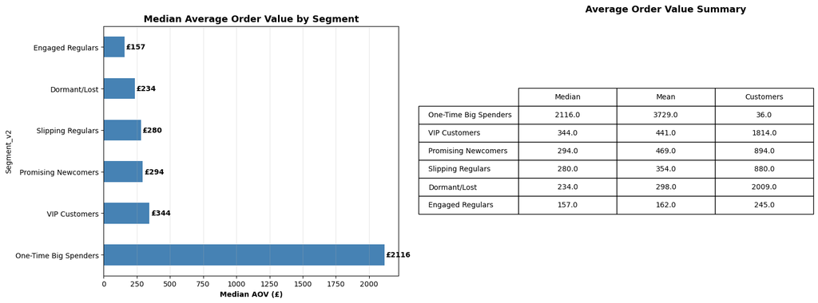

```
Average Order Value by Segment:
                       Median    Mean  Customers
Segment_v2
One-Time Big Spenders  2116.0  3729.0         36
VIP Customers           344.0   441.0       1814
Promising Newcomers     294.0   469.0        894
Slipping Regulars       280.0   354.0        880
Dormant/Lost            234.0   298.0       2009
Engaged Regulars        157.0   162.0        245
```

```python
#Visualzining the AOV
# Remove extreme outliers for clean visualization
threshold_99 = rfm_clean['Avg_Order_Value'].quantile(0.99)
rfm_viz = rfm_clean[rfm_clean['Avg_Order_Value'] <= threshold_99]

# Create comparison charts
fig, axes = plt.subplots(1, 2, figsize=(16, 6))

# Chart 1: Median AOV by Segment
median_aov = rfm_clean.groupby('Segment_v2')['Avg_Order_Value'].median().sort_values(ascending=False)

median_aov.plot(kind='barh', ax=axes[0], color='steelblue')
axes[0].set_title('Median Average Order Value by Segment', fontweight='bold', fontsize=13)
axes[0].set_xlabel('Median AOV (£)', fontweight='bold')
axes[0].grid(axis='x', alpha=0.3)

# Add value labels
for i, v in enumerate(median_aov.values):
    axes[0].text(v + 10, i, f'£{v:.0f}', va='center', fontweight='bold')

# Chart 2: Summary Table as Heatmap (visual table)
aov_summary = rfm_clean.groupby('Segment_v2')['Avg_Order_Value'].agg(['median', 'mean', 'count']).round(0)
aov_summary.columns = ['Median', 'Mean', 'Customers']
aov_summary = aov_summary.sort_values('Median', ascending=False)

# Display as text table on the plot
axes[1].axis('tight')
axes[1].axis('off')
table = axes[1].table(cellText=aov_summary.values,
                      rowLabels=aov_summary.index,
                      colLabels=aov_summary.columns,
                      cellLoc='center',
                      loc='center')
table.auto_set_font_size(False)
table.set_fontsize(10)
table.scale(1, 2)
axes[1].set_title('Average Order Value Summary', fontweight='bold', fontsize=13, pad=20)

plt.tight_layout()
plt.show()

# Also print the table
print("\nAverage Order Value by Segment:")
print(aov_summary)
```

```python
monetary_data = rfm_clean.groupby('Segment_v2')[['Monetary']].sum()
monetary_data['percentage']=monetary_data['Monetary']/sum(monetary_data['Monetary']) * 100
monetary_data
```

| Segment_v2 | Monetary | percentage |
| --- | --- | --- |
| Dormant/Lost | 8.751555e+05 | 4.932280 |
| Engaged Regulars | 1.529210e+05 | 0.861846 |
| One-Time Big Spenders | 2.601736e+05 | 1.466310 |
| Promising Newcomers | 7.699532e+05 | 4.339371 |
| Slipping Regulars | 2.221679e+06 | 12.521138 |
| VIP Customers | 1.346355e+07 | 75.879056 |

# SEGMENT INSIGHTS & BUSINESS RECOMMENDATIONS

CUSTOMER SEGMENT ANALYSIS & RECOMMENDATIONS

1. VIP CUSTOMERS Profile

Size: 1,814 customers (30.9% of customer base) Definition: RFM scores in third quartile or better across all metrics Purchase Behavior:

Average Order Value: £344 (median)

Business Value

Revenue Contribution: 75% of total revenue Strategic Importance: CRITICAL - Core revenue foundation Customer Lifetime Value: £7,000+ per customer

Key Insight VIP customers represent less than one-third of the customer base but generate three-quarters of revenue. This segment demonstrates strong loyalty with frequent, consistent purchasing behavior and high lifetime value. Protecting and growing this segment is the highest business priority. Recommended Actions

1. VIP Retention Program

Tactic: Exclusive loyalty benefits (early sale access, dedicated support, personalized offers) Rationale: Retention is 5-7x cheaper than acquisition; VIPs already trust the brand Expected Impact: Increase retention from 85% to 95% = preserve £525K+ annual revenue

2. Lifetime Value Expansion

3. Proactive At-Risk Monitoring

Tactic: Alert system when VIP inactive for 45+ days; automated engagement outreach Rationale: Prevent VIPs from slipping to lower-value segments Expected Impact: Reduce churn by 15% = £394K revenue saved

Success Metrics

Monthly VIP retention rate (target: 95%+) Average purchase frequency (maintain 12+ transactions/year) AOV growth trajectory (target: +10% within 6 months)

2. SLIPPING REGULARS Profile

Size: 880 customers (15.0% of customer base) Definition: Historically frequent buyers (F≥3) who haven't purchased in 97+ days Historical Value:

Average lifetime spend: £2,500 per customer Previously active, now dormant

Average Order Value: £280 (median)

Business Value

Key Insight - Price Is NOT The Churn Driver Analysis of 4,442 products purchased by Slipping Regulars revealed:

0% discontinued - all products remain available for purchase 79% stable pricing - majority experienced no price changes 14.5% price decreases >10% vs 5.4% increases - products got cheaper, customers still left

Conclusion: Price increases and product availability are not primary churn drivers. Alternative hypotheses include competitive switching, natural purchase lifecycle completion, service quality issues, or life circumstance changes. Recommended Actions

1. Strategic Win-Back Campaign

Tactic: Experience-focused outreach (NOT discount-driven, since price isn't the issue)

"We've improved shipping times" "New products in categories you loved" Personalized "We miss you" messaging with product recommendations

Rationale: Data shows price sensitivity is low; focus on value proposition and customer experience Expected Impact: 30% recovery rate (264 customers) × £2,500 avg value = £660K recovered revenue

2. Churn Root Cause Analysis

Tactic: Exit surveys, customer interviews, competitive analysis Rationale: Understanding true churn drivers enables targeted retention strategies Expected Impact: Inform future retention programs; reduce ongoing churn by 20%

3. Competitive Monitoring

Tactic: Track where customers are going (social listening, market research) Rationale: Identify service gaps or competitor advantages Expected Impact: Close experience gaps that drive customer departure

Success Metrics

Win-back campaign response rate (target: 25%+) Recovered customer reactivation rate (target: 30%) 90-day retention of reactivated customers (target: 70%+)

3. ENGAGED REGULARS Profile

Size: 245 customers (4.2% of customer base) Definition: High purchase frequency + recent activity (last 96 days) + low monetary value Purchase Behavior:

Average lifetime spend: £624 per customer High frequency, recent purchases Low transaction values per order

Average Order Value: £157 (median) - lowest of all active segments

Business Value

Key Insight - The Low-Basket Opportunity Engaged Regulars demonstrate strong purchase habits but minimal transaction value. Median AOV of £157 is:

54% below VIP customers (£157 vs £344) 44% below Slipping Regulars (£157 vs £280)

This segment is already engaged (frequent, recent purchases) but undermonetized. They trust the brand and buy regularly—they simply need incentive to spend more per transaction. Revenue Math:

Each £10 AOV increase = 245 customers × 6 purchases/year × £10 = £14,700 annual revenue Target: £157 → £250 AOV (59% increase) = £136,710 incremental revenue

Recommended Actions

1. Intelligent Bundling Strategy

Tactic:

Create product bundles at £200-250 price points "Buy 3, save 15%" offers "Starter kit" packages in popular categories

Rationale: Customers already buy frequently; make it easy to buy more per visit Expected Impact: Increase AOV from £157 → £200 (27% lift) = £63,210 incremental revenue

2. Free Shipping Threshold

Tactic: Set free shipping at £180 (just above current median) Rationale: Encourages adding 1-2 items to reach threshold; proven e-commerce tactic Expected Impact: 40% of customers add items to qualify; £25 avg basket increase = £14,700 revenue

3. "Complete The Look" Recommendations

Tactic: Personalized cross-sell at checkout based on purchase history Rationale: Low-friction upsell to customers already committed to buying Expected Impact: 20% take rate on £30 avg recommendations = £8,820 revenue

Combined Expected Impact: £86,730 incremental annual revenue (57% segment revenue increase) Success Metrics

Average Order Value growth (target: £157 → £220 within 6 months) Bundle attachment rate (target: 30%+ of purchases include bundles) Free shipping threshold utilization (target: 50%+ of orders)

STRATEGIC PRIORITIES SUMMARY Priority 1: Protect VIP Customers (75% of revenue at risk)

Expected ROI: Highest - preserve £525K+ with retention program

Priority 2: Recover Slipping Regulars (£2.2M value at risk)

Expected ROI: High - £660K recovery with 30% win-back rate

Priority 3: Monetize Engaged Regulars (Untapped £137K opportunity)

Expected ROI: Medium - £87K incremental with basket-building tactics

Total Potential Revenue Impact: £1.27M+